# US Border Apprehension Analysis

February 17, 2018

## **INTRODUCTION**

Illegal entry to the United States has been of great concern to the US customs and border protection unit. Our analysis below will clarify if the recent enforcement of the immigration Laws by president had a positive effect on the border apprenshions between the two years.

## **Contents**

- Review of Apprehensions in 2010
- Review of Apprehensions in 2017
- Graphical comparison of border apprehensions by sector
- Graphical comparison of border apprehensions by Month
- T-Test Analysis
- T-Test Analysis Continued

## Review of Apprehensions 2010

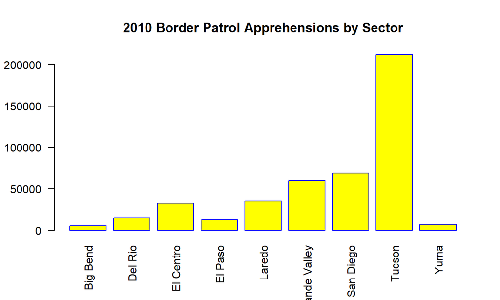

## Review of Apprehensions 2017

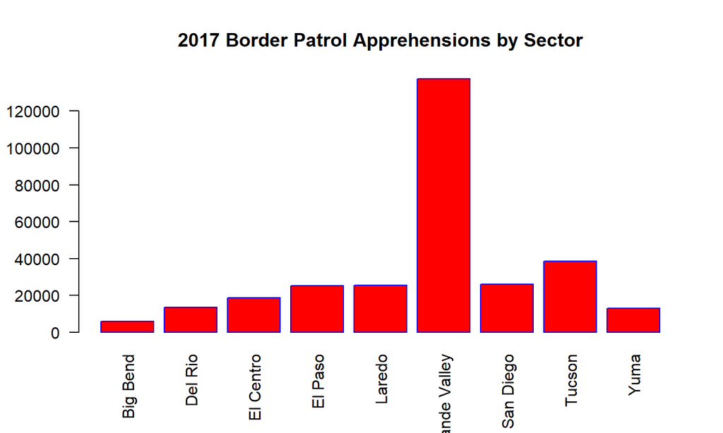

## **Graphical comparison of border apprehensions by sector**

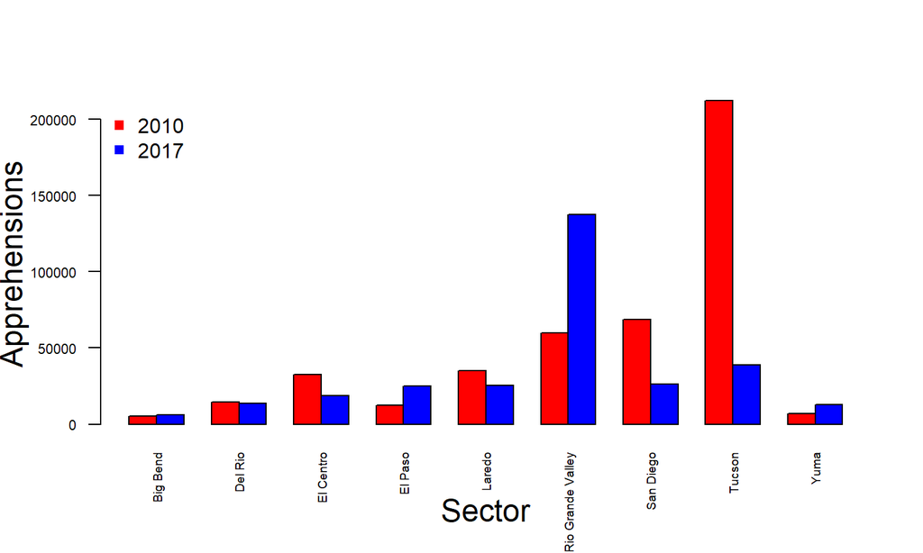

## **Graphical comparison of border apprehensions by Month**

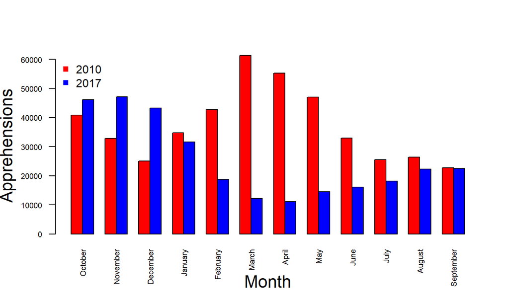

## **T-Test Analysis**

### Max Apprehensions by Sector between 2010 and 2017

```
##
##  Two Sample t-test
##
## data:  maxsect2010 and maxsect2017
## t = 1.9547, df = 22, p-value = 0.06344
## alternative hypothesis: true difference in means is not equal to 0
## 95 percent confidence interval:
##   -379.1203 12819.1203
## sample estimates:
## mean of x mean of y
##   17683.5   11463.5
```

The results show that there is not a significant difference in means between the two sectors(Tucson 2010, Rio Grande Valley 2017) with Max apprehensions in 2010 and 2017

## **T-Test Analysis Continued**

### Max Apprehensions by 3-Month Period between 2010 and 2017

```
##
##  Two Sample t-test
##
## data:  max3mnth2010 and max3mnth2017
## t = 0.48741, df = 52, p-value = 0.628
## alternative hypothesis: true difference in means is not equal to 0
## 95 percent confidence interval:
##  -3116.650  5116.427
## sample estimates:
## mean of x mean of y
##  6060.852  5060.963
```

The 3-month period in 2010 with max apprehensions was March, April, and May. The 3-month period in 2017 with max apprehensions was October, November, December. Based on the t-test, the results show that there is no significant difference in means between these two 3-month periods.

## **Time Series**

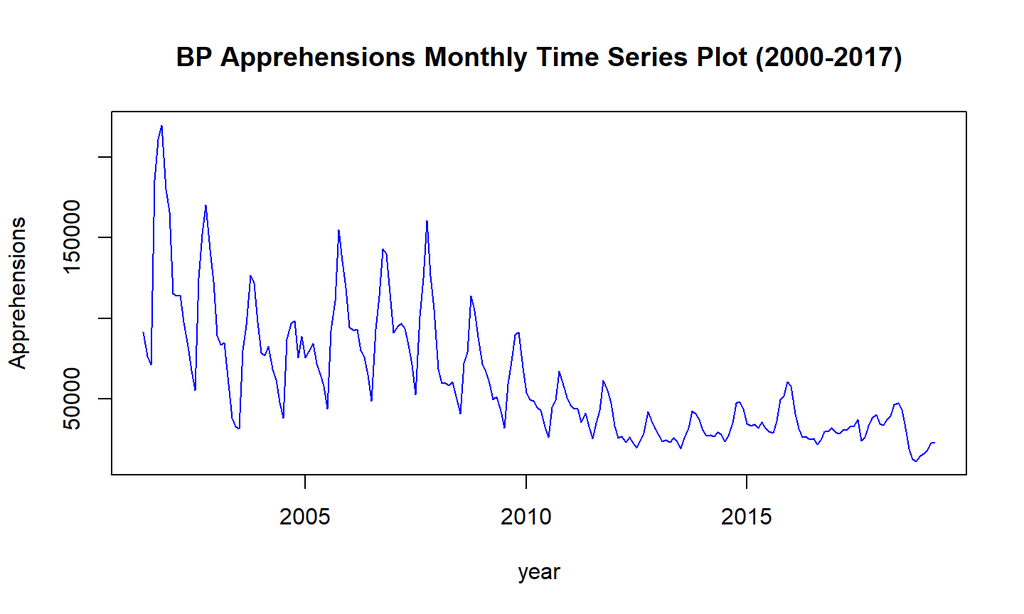